```python
# # install packages
# import sys

# !conda install --yes --prefix {sys.prefix} numpy scipy pandas matplotlib seaborn pydotplus
```

# Visualizing Decision Boundaries w. Scikit-learn + Half Moon Dataset

#### Victor Xu, Post 3/1/19

```python
# importing libraries
import os
import io
import warnings

import numpy as np
import scipy as sp
import pandas as pd
import sklearn as sk

import matplotlib as mpl
import matplotlib.pyplot as plt
from matplotlib.colors import ListedColormap
%matplotlib inline
import seaborn as sns
sns.set()

# evaluation metrics
from sklearn.metrics import mean_squared_error
from sklearn.metrics import r2_score
from sklearn.metrics import accuracy_score
from sklearn.metrics import roc_auc_score

# grid search for model selection
from sklearn.model_selection import GridSearchCV

# linear regression
from sklearn.linear_model import LinearRegression

# logistic regression
from sklearn.linear_model import LogisticRegression

# decision tree
from sklearn.tree import DecisionTreeClassifier
from sklearn.tree import DecisionTreeRegressor

# random forest
from sklearn.ensemble import RandomForestClassifier
from sklearn.ensemble import RandomForestRegressor

# adaboost and gradient boosting
from sklearn.ensemble import AdaBoostClassifier
from sklearn.ensemble import GradientBoostingClassifier
from sklearn.ensemble import GradientBoostingRegressor

warnings.simplefilter(action='ignore', category=FutureWarning)
```

## Linear Regression

### Load and visualize the data

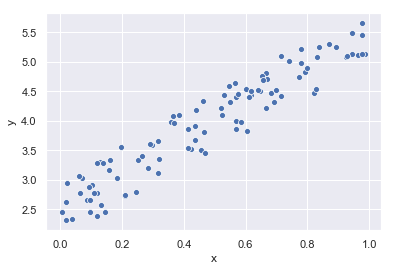

```python
# load data
data = pd.read_csv('https://raw.githubusercontent.com/zariable/UW-MSIS522/master/lab/data/linear_regression_data.csv')

# visualize
sns.scatterplot(data.x, data.y)
```

### Train linear regression model

```
Slope: [2.93655106]
Intercept: 2.5580800241570225
```

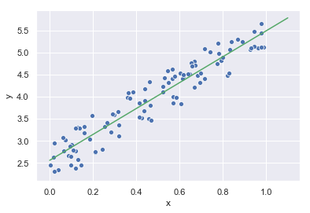

```python
# model initialization
linear_regression_model = LinearRegression()

# fit the data(train the model)
linear_regression_model.fit(data.loc[:, ['x']], data['y'])

# print values
print('Slope: {}'.format(linear_regression_model.coef_))
print('Intercept: {}'.format(linear_regression_model.intercept_))

# visualize the linear model
x_plot = np.linspace(0, 1.1, 100)
y_plot = linear_regression_model.coef_[0] * x_plot + linear_regression_model.intercept_
sns.lineplot(x_plot, y_plot, color='g')
sns.scatterplot(data.x, data.y)
```

### Predict with a linear regression model

```python
# predict
z = linear_regression_model.predict(data.loc[:, ['x']])
y = data['y']
```

### Evaluate the model performance on the training set

Mean Squared Error (MSE) is the average of the sum of the squares of residuals, which is defined by

\begin{align} MSE = \frac{1}{N}\sum_{i=1}^N(y_i - z_i)^2 \end{align}

$R^2$ score or the coefficient of determination explains how much the total variance of the dependent variable can be reduced by using the linear regression. $R^2$ is determined by

\begin{align} R^2 = 1 - \frac{SS_r}{SS_t} \end{align}

where $SS_r = \sum_{i=1}^N (y_i - \bar{y})^2$ is the total sum of errors if we take the mean of the observed values as the predicted value and $SS_r = \sum_{i=1}^N (y_i - z_i)^2$ is the sum of square of residuals.

#### Quiz: define two functions in python: one for MSE and one for $R^2$.

```python
# code up RMSE and R2
def mse(y, z):
    return np.mean((y - z)**2)

def r2(y, z):
    ssr = np.sum((y - z)**2)
    sst = np.sum((y - np.mean(y))**2)
    return 1 - (ssr / sst)

print('mean squared error: {}'.format(mse(y, z)))
print('R2 score: {}'.format(r2(y, z)))
```

```
mean squared error: 0.07623324582875006
R2 score: 0.9038655568672764
```

```python
# use scikit learn's implementation
mse = mean_squared_error(y, z)
r2 = r2_score(y, z)

print('mean squared error: {}'.format(mse))
print('R2 score: {}'.format(r2))
```

```
mean squared error: 0.0762332458287501
R2 score: 0.9038655568672764
```

## Half Moon Dataset

### Load and visualize the data

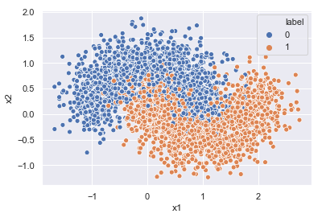

```python
train_data = pd.read_csv('https://raw.githubusercontent.com/zariable/UW-MSIS522/master/lab/data/halfmoon_train.csv')
train_x = train_data.loc[:,['x1', 'x2']]
train_y = train_data.loc[:,'label']

# visualize
sns.scatterplot(train_data.x1, train_data.x2, hue=train_data.label)
```

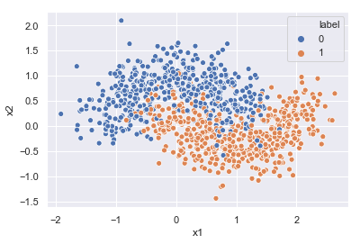

```python
test_data = pd.read_csv('https://raw.githubusercontent.com/zariable/UW-MSIS522/master/lab/data/halfmoon_test.csv')
test_x = test_data.loc[:,['x1', 'x2']]
test_y = test_data.loc[:,'label']

# visualize
sns.scatterplot(test_data.x1, test_data.x2, hue=test_data.label)
```

## Logistic Regression

### Train Logistic Regression Model

In this exercise, we will use [LogisticRegression](https://scikit-learn.org/stable/modules/generated/sklearn.linear_model.LogisticRegression.html) API in scikit-learn to train a logistic regression model.

```python
# model initialization
logistic_regression_model = LogisticRegression()

# train the model
logistic_regression_model.fit(train_data.loc[:, ['x1', 'x2']], train_data['label'])

# print model parameters
print('Slope: {}'.format(logistic_regression_model.coef_))
print('Intercept: {}'.format(logistic_regression_model.intercept_))
```

```
Slope: [[ 1.27891789 -3.68118041]]
Intercept: [0.29526604]
```

### Visualize the decision boundary

```python
# helper functions used to plot decision boundary
def plot_decision_boundary(clf, X, y, axes=[-1.5, 2.5, -1, 1.5], alpha=0.5, contour=True):
    """
    Plot the decision boundary of a learnt classifier
    """
    if isinstance(X, pd.DataFrame):
        X = X.values
    if isinstance(y, pd.Series):
        y = y.values

    x1s = np.linspace(axes[0], axes[1], 100)
    x2s = np.linspace(axes[2], axes[3], 100)
    x1, x2 = np.meshgrid(x1s, x2s)
    X_new = np.c_[x1.ravel(), x2.ravel()]
    y_pred = clf.predict(X_new).reshape(x1.shape)
    custom_cmap = ListedColormap(['#fafab0','#9898ff','#a0faa0'])
    plt.contourf(x1, x2, y_pred, alpha=0.3, cmap=custom_cmap)
    if contour:
        custom_cmap2 = ListedColormap(['#7d7d58','#4c4c7f','#507d50'])
        plt.contour(x1, x2, y_pred, cmap=custom_cmap2, alpha=1)
    plt.plot(X[:, 0][y==0], X[:, 1][y==0], "yo", alpha=alpha)
    plt.plot(X[:, 0][y==1], X[:, 1][y==1], "bs", alpha=alpha)
    plt.axis(axes)
    plt.xlabel(r"$x_1$", fontsize=18)
    plt.ylabel(r"$x_2$", fontsize=18, rotation=0)
```

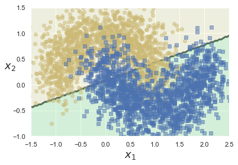

```python
# visualize the linear model
plot_decision_boundary(logistic_regression_model, train_x, train_y)
```

### Predict with LR model

```python
train_z = logistic_regression_model.predict(train_x)
test_z = logistic_regression_model.predict(test_x)
```

### Evaluate LR model

Now we evaluate the model performance on test data

```python
print("model accuracy on train set: {}".format(accuracy_score(train_y, train_z)))
print("model accuracy on test set: {}".format(accuracy_score(test_y, test_z)))
```

```
model accuracy on train set: 0.8463333333333334
model accuracy on test set: 0.84
```

## Decision Tree (DT)

### Train DT model

```python
# model initialization
dt_model = DecisionTreeClassifier(max_depth=2)

# train the model
dt_model.fit(train_x, train_y)
```

```
DecisionTreeClassifier(class_weight=None, criterion='gini', max_depth=2,
            max_features=None, max_leaf_nodes=None,
            min_impurity_decrease=0.0, min_impurity_split=None,
            min_samples_leaf=1, min_samples_split=2,
            min_weight_fraction_leaf=0.0, presort=False, random_state=None,
            splitter='best')
```

### Visualize the decision boundary

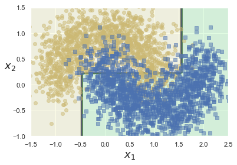

```python
plot_decision_boundary(dt_model, train_x, train_y)
```

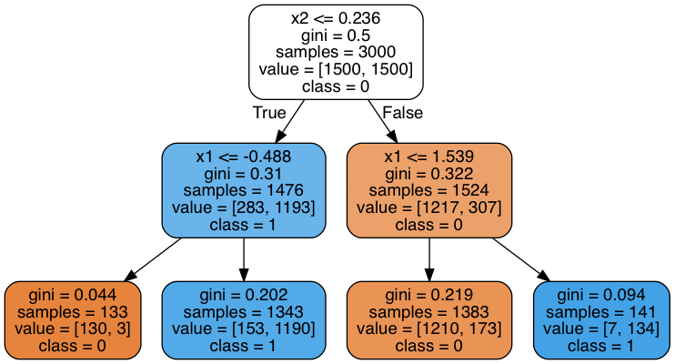

```python
from sklearn.externals.six import StringIO
from IPython.display import Image
from sklearn.tree import export_graphviz
import pydotplus

dot_data = StringIO()
feature_names = train_x.columns
class_names = train_y.unique().astype('U')
class_names.sort()
export_graphviz(dt_model, out_file=dot_data, feature_names=feature_names, class_names=class_names, filled=True, rounded=True)
graph = pydotplus.graph_from_dot_data(dot_data.getvalue())
Image(graph.create_png())
```

### Predict with DT model

```python
train_z = dt_model.predict(train_x)
train_z_prob = dt_model.predict_proba(train_x)[:,1]

test_z = dt_model.predict(test_x)
test_z_prob = dt_model.predict_proba(test_x)[:,1]
```

### Evaluate DT model

```python
print("model accuracy on train set: {}".format(accuracy_score(train_y, train_z)))
print("model ROC AUC on test set: {}".format(roc_auc_score(train_y, train_z_prob)))
print("model accuracy on test set: {}".format(accuracy_score(test_y, test_z)))
print("model ROC AUC on test set: {}".format(roc_auc_score(test_y, test_z_prob)))
```

```
model accuracy on train set: 0.888
model ROC AUC on test set: 0.8948959999999999
model accuracy on test set: 0.892
model ROC AUC on test set: 0.8990000000000001
```

### Hyper-parameter tuning

```python
parameters = {
    "max_depth": [2, 4],
    "min_samples_split": [0.05, 0.1, 0.2]
}

dtc = DecisionTreeClassifier()
dtc_grid = GridSearchCV(dtc, parameters, cv=3)
dtc_grid.fit(train_x, train_y)

# summarize the results of the grid search
print("The best score is {}".format(dtc_grid.best_score_))
print("The best hyper parameter setting is {}".format(dtc_grid.best_params_))
```

```
The best score is 0.8853333333333333
The best hyper parameter setting is {'max_depth': 2, 'min_samples_split': 0.05}
```

```python
train_z = dtc_grid.predict(train_x)
train_z_prob = dtc_grid.predict_proba(train_x)[:,1]

test_z = dtc_grid.predict(test_x)
test_z_prob = dtc_grid.predict_proba(test_x)[:,1]
```

```python
print("model accuracy on train set: {}".format(accuracy_score(train_y, train_z)))
print("model ROC AUC: {}".format(roc_auc_score(train_y, train_z_prob)))
print("model accuracy on test set: {}".format(accuracy_score(test_y, test_z)))
print("model ROC AUC: {}".format(roc_auc_score(test_y, test_z_prob)))
```

```
model accuracy on train set: 0.888
model ROC AUC: 0.8948959999999999
model accuracy on test set: 0.892
model ROC AUC: 0.8990000000000001
```

## Random Forest (RF)

A random forest is a meta estimator that fits a number of decision tree classifiers on various sub-samples of the dataset and uses averaging to improve the predictive accuracy and control over-fitting. The sub-sample size is always the same as the original input sample size but the samples are drawn with replacement if bootstrap=True (default). Please refer to the [scikit-learn doc](https://scikit-learn.org/stable/modules/generated/sklearn.ensemble.RandomForestClassifier.html) for more details on how to use the API.

### Train RF model

```python
parameters = {
    "n_estimators": [20, 200],
    "max_depth": [2, 4],
    "min_samples_split": [0.05, 0.1, 0.2]
}

rfc_grid = GridSearchCV(RandomForestClassifier(n_jobs=-1, random_state=0), parameters, cv=3)
rfc_grid.fit(train_x, train_y)

# summarize the results of the grid search
print("The best score is {}".format(rfc_grid.best_score_))
print("The best hyper parameter setting is {}".format(rfc_grid.best_params_))
```

```
The best score is 0.889
The best hyper parameter setting is {'max_depth': 4, 'min_samples_split': 0.05, 'n_estimators': 20}
```

### Visualize the decision boundary

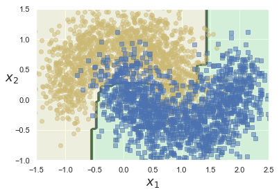

```python
plot_decision_boundary(rfc_grid, train_x.values, train_y.values)
```

### Predict with RF model

Make prediction and evaluate the model performance on test data.

```python
# TODO: make prediction and evaluate the model performance on test data
train_z = rfc_grid.predict(train_x)
train_z_prob = rfc_grid.predict_proba(train_x)[:,1]

test_z = rfc_grid.predict(test_x)
test_z_prob = rfc_grid.predict_proba(test_x)[:,1]
```

### Evaluate RF model

```python
print("model accuracy on train set: {}".format(accuracy_score(train_y, train_z)))
print("model ROC AUC: {}".format(roc_auc_score(train_y, train_z_prob)))
print("model accuracy on test set: {}".format(accuracy_score(test_y, test_z)))
print("model ROC AUC: {}".format(roc_auc_score(test_y, test_z_prob)))
```

```
model accuracy on train set: 0.8896666666666667
model ROC AUC: 0.9635162222222221
model accuracy on test set: 0.89
model ROC AUC: 0.951494
```

## AdaBoost

**In this exercise, we will apply AdaBoost classifier in scikit-learn to classify the synthetic moon dataset.**

### Train AdaBoost model

[Adaboost](https://scikit-learn.org/stable/modules/generated/sklearn.ensemble.AdaBoostClassifier.html) algorithm works by learning each base learner so that it corrects the mis-classified data points from previous classifiers, and use weighted voting of predictions from each base learners for the final prediction.

There are two key hyper-parameters:

- n_estimators: The maximum number of estimators at which boosting is terminated. In case of perfect fit, the learning procedure is stopped early.
- learning_rate: Learning rate shrinks the contribution of each classifier by learning_rate. There is a trade-off between learning_rate and n_estimators.

```python
# TODO: fine-tune Adaboost with decision tree (max_depth=4) as base learners using grid search with cross-validation (GridSearchCV).
parameters = {
    "n_estimators": [20, 40],
    "learning_rate": [0.01, 0.1, 1, 10]
}

adaboost = AdaBoostClassifier(DecisionTreeClassifier(max_depth=4), random_state=0)
adaboost_grid = GridSearchCV(adaboost, parameters, cv=3)
adaboost_grid.fit(train_x, train_y)

# summarize the results of the grid search
print("The best score is {}".format(adaboost_grid.best_score_))
print("The best hyper parameter setting is {}".format(adaboost_grid.best_params_))
```

```
The best score is 0.9016666666666666
The best hyper parameter setting is {'learning_rate': 0.1, 'n_estimators': 20}
```

Visualize the decision boundaries.

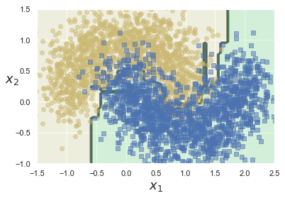

```python
# plot the decision boundary
plot_decision_boundary(adaboost_grid, train_x.values, train_y.values)
```

Now let's use the fine-tuned model to make predictions on the test dataset and evaluate its performance in terms of accuracy and ROC AUC.

```python
# TODO: make prediction and evaluate the model performance on test data
test_z = adaboost_grid.predict(test_x)
test_z_prob = adaboost_grid.predict_proba(test_x)[:,1]

print("model accuracy: {}".format(accuracy_score(test_y, test_z)))
print("model ROC AUC: {}".format(roc_auc_score(test_y, test_z_prob)))
```

```
model accuracy: 0.899
model ROC AUC: 0.959744
```